# Introduction to the GenomicRanges package MonBUG presentation

Febuary 3, 2016

## Introduction

- GenomicRanges is a Bioconductor package defining general purpose containers and functions for manipulating genomic intervals and associated annotations
- Time and memory efficient (can handle high-throughput sequencing data)
- Many R packages dedicated to genomic analysis rely on this package
- If you do your downstream analysis with R, it can spare you from going back and forward between RStudio, Perl/Python/Bedtools scripts and your intermediate results files
- Authors: P. Aboyoun, H. Pagès, and M. Lawrence

## GRanges object

A GRanges object is a *vector* of genomic intervals and associated annotations.

Each element (interval) in the vector is comprised of

- a sequence name (e.g. chr1)
- a range (start & end)
- a strand (+, -, *)
- optional metadata columns (e.g. score, GC content, etc.).

## Creating GRanges objects

Lets start by creating a GRanges with a single interval.

```r
library(GenomicRanges)
```

```r
gr <- GRanges(seqnames = "chr1",
              ranges = IRanges(50,100),
              strand = "+")
gr
```

```
## GRanges object with 1 range and 0 metadata columns:
##       seqnames    ranges strand
##          <Rle> <IRanges>  <Rle>
##   [1]     chr1 [50, 100]      +
##   -------
##   seqinfo: 1 sequence from an unspecified genome; no seqlengths
```

## Creating GRanges objects

When providing multiple ranges, *seqnames* and *strand* are recycled by the constructor if they are not vectors.

```r
gr <- GRanges(seqnames = "chr1",
              ranges = IRanges( 10:101, 15:106 ),strand = "-")
gr
```

```
## GRanges object with 92 ranges and 0 metadata columns:
##        seqnames     ranges strand
##           <Rle>  <IRanges>  <Rle>
##    [1]     chr1   [10, 15]      -
##    [2]     chr1   [11, 16]      -
##    [3]     chr1   [12, 17]      -
##    [4]     chr1   [13, 18]      -
##    [5]     chr1   [14, 19]      -
##    ...      ...        ...    ...
##   [88]     chr1 [ 97, 102]      -
##   [89]     chr1 [ 98, 103]      -
##   [90]     chr1 [ 99, 104]      -
##   [91]     chr1 [100, 105]      -
##   [92]     chr1 [101, 106]      -
##   -------
##   seqinfo: 1 sequence from an unspecified genome; no seqlengths
```

## Rle

Rle is a simple form of lossless data compression in which runs of identical values are stored as (value ; run_length) pairs

```r
x = c(rep(1,50),rep(0,40),rep(1,30))
x
```

```
##   [1] 1 1 1 1 1 1 1 1 1 1 1 1 1 1 1 1 1 1 1 1 1 1 1 1 1 1 1 1 1 1 1 1 1 1 1
##  [36] 1 1 1 1 1 1 1 1 1 1 1 1 1 1 1 0 0 0 0 0 0 0 0 0 0 0 0 0 0 0 0 0 0 0 0
##  [71] 0 0 0 0 0 0 0 0 0 0 0 0 0 0 0 0 0 0 0 0 1 1 1 1 1 1 1 1 1 1 1 1 1 1 1
## [106] 1 1 1 1 1 1 1 1 1 1 1 1 1 1 1
```

```r
Rle(x)
```

```
## numeric-Rle of length 120 with 3 runs
##   Lengths: 50 40 30
##   Values :  1  0  1
```

## GRanges accessors

start(), end(), strand(), seqnames(), length()

```r
length(gr)
```

```
## [1] 92
```

```r
strand(gr)
```

```
## factor-Rle of length 92 with 1 run
##   Lengths: 92
##   Values :  -
## Levels(3): + - *
```

```r
start(gr)[1:20]
```

```
##  [1] 10 11 12 13 14 15 16 17 18 19 20 21 22 23 24 25 26 27 28 29
```

## GRanges annotations

Single *annotation* column can be set/get with $

```r
gr$score = 10:101
gr$dataset = "TP53_ChIPseq"
gr
```

```
## GRanges object with 92 ranges and 2 metadata columns:
##        seqnames     ranges strand   |     score      dataset
##           <Rle>  <IRanges>  <Rle>   | <integer>  <character>
##    [1]     chr1   [10, 15]      -   |        10 TP53_ChIPseq
##    [2]     chr1   [11, 16]      -   |        11 TP53_ChIPseq
##    [3]     chr1   [12, 17]      -   |        12 TP53_ChIPseq
##    [4]     chr1   [13, 18]      -   |        13 TP53_ChIPseq
##    [5]     chr1   [14, 19]      -   |        14 TP53_ChIPseq
##    ...      ...        ...    ... ...       ...          ...
##   [88]     chr1 [ 97, 102]      -   |        97 TP53_ChIPseq
##   [89]     chr1 [ 98, 103]      -   |        98 TP53_ChIPseq
##   [90]     chr1 [ 99, 104]      -   |        99 TP53_ChIPseq
##   [91]     chr1 [100, 105]      -   |       100 TP53_ChIPseq
##   [92]     chr1 [101, 106]      -   |       101 TP53_ChIPseq
##   -------
##   seqinfo: 1 sequence from an unspecified genome; no seqlengths
```

## GRanges annotations

The annotations are stored in a *DataFrame* that can be accessed with *mcols()*

```r
mcols(gr)
```

```
## DataFrame with 92 rows and 2 columns
##         score      dataset
##     <integer>  <character>
## 1          10 TP53_ChIPseq
## 2          11 TP53_ChIPseq
## 3          12 TP53_ChIPseq
## 4          13 TP53_ChIPseq
## 5          14 TP53_ChIPseq
## ...       ...          ...
## 88         97 TP53_ChIPseq
## 89         98 TP53_ChIPseq
## 90         99 TP53_ChIPseq
## 91        100 TP53_ChIPseq
## 92        101 TP53_ChIPseq
```

## Combining GRanges objects

Just like with *base::vector*, we can use the *c()* function

```r
gr.b = gr
gr.b$dataset = "MYC_ChIPseq"

gr.combined = c( gr, gr.b )
gr.combined
```

```
## GRanges object with 184 ranges and 2 metadata columns:
##         seqnames     ranges strand   |     score      dataset
##            <Rle>  <IRanges>  <Rle>   | <integer>  <character>
##     [1]     chr1   [10, 15]      -   |        10 TP53_ChIPseq
##     [2]     chr1   [11, 16]      -   |        11 TP53_ChIPseq
##     [3]     chr1   [12, 17]      -   |        12 TP53_ChIPseq
##     [4]     chr1   [13, 18]      -   |        13 TP53_ChIPseq
##     [5]     chr1   [14, 19]      -   |        14 TP53_ChIPseq
##     ...      ...        ...    ... ...       ...          ...
##   [180]     chr1 [ 97, 102]      -   |        97  MYC_ChIPseq
##   [181]     chr1 [ 98, 103]      -   |        98  MYC_ChIPseq
##   [182]     chr1 [ 99, 104]      -   |        99  MYC_ChIPseq
##   [183]     chr1 [100, 105]      -   |       100  MYC_ChIPseq
##   [184]     chr1 [101, 106]      -   |       101  MYC_ChIPseq
##   -------
##   seqinfo: 1 sequence from an unspecified genome; no seqlengths
```

## Transformations on GRanges objects

We first create 3 GRanges objects each consisting of 20 intervals distributed around some locations (75, 200 and 275).

```r
start.a = rnorm(n = 20, mean = 75, sd = 35)
start.b = rnorm(n = 20, mean = 200, sd = 20)
start.c = rnorm(n = 20, mean = 275, sd = 15)

gr.a = GRanges("seq1", IRanges(start.a, start.a + 50), "+")
gr.b = GRanges("seq1", IRanges(start.b, start.b + 50), "-") # on minus strand
gr.c = GRanges("seq1", IRanges(start.c, start.c + 50), "+")

gr.abc = c(gr.a, gr.b, gr.c) #combined
```

## Simple plotting function

We define a simple plotting function

```r
gr.plot = function(gr,xlim=range(c(start(gr),end(gr))),...){
  #Find y lim for plotting region
  ylim = c(0,length(gr)+2)

  #Init empty plot
  plot(0,ylim=ylim,yaxt="n",ylab="", xlab="Genomic position",col="white", xlim=xlim, ...)
  if(length(gr)>0){
  #Draw ranges using rect()
  rect(start(gr), #left coordinate
       1:length(gr), #y bottom
       end(gr), #right coordinate
       2:(length(gr)+1),#y top
       col=1+as.numeric(as.factor(strand(gr))),
       border = "black")}
  legend("topleft",legend = c("+","-","*"),fill=2:4)
}
```

## Our 3 GRanges objects

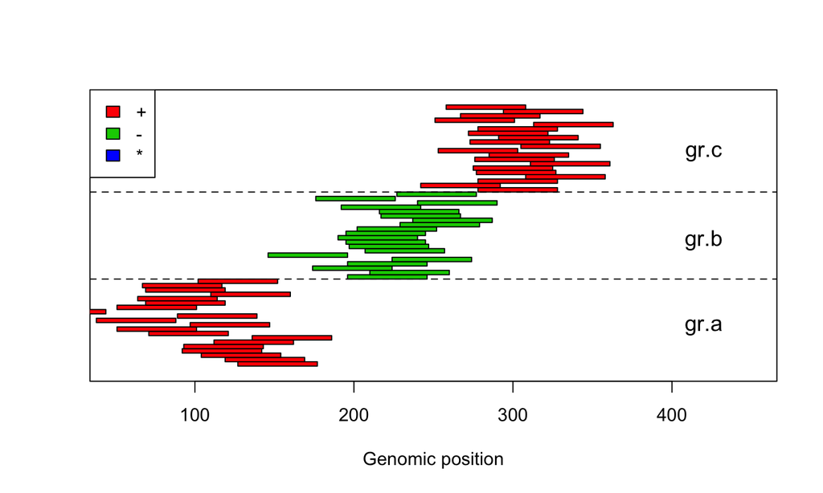

```r
gr.plot(gr.abc, xlim=c(50,450))
text(x=420,y=c(10,30,50),c("gr.a","gr.b","gr.c"),cex = 1.2)
abline(lty=2,h=c(21,41))
```

## Intra range transformations

These are applied to each range individually and the returned GRanges object has the same length as the input object

- shift()
- resize()

## Shifting GRanges coordinates

```r
gr.b2 = shift(gr.b,300)
```

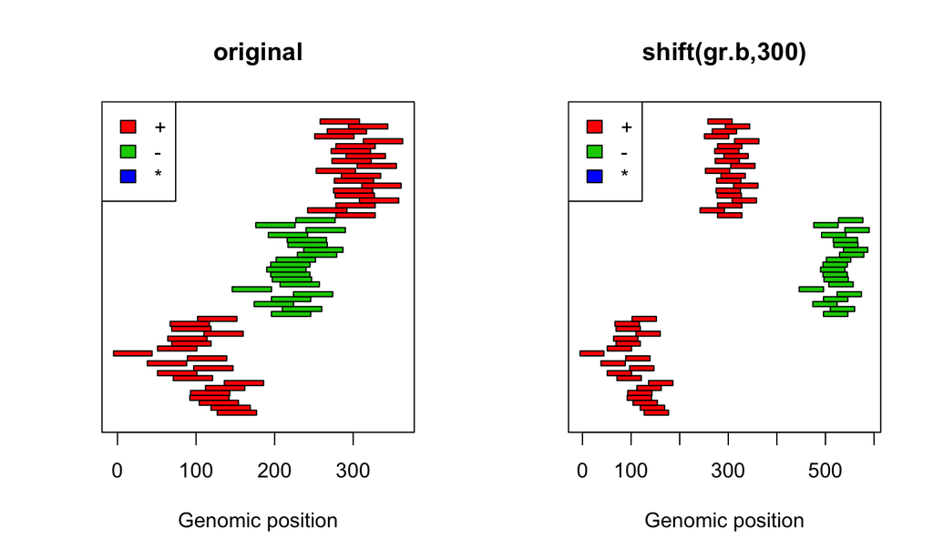

## Resizing GRanges elements

```r
gr.b2 = resize(gr.b,200,"center")
```

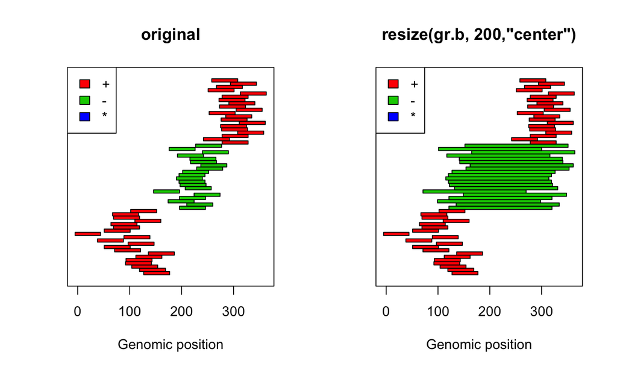

## Inter range transformations

These transforms all the ranges together as a set to produce a new set of ranges, returned in a GRanges object not necessarily of the same lenght.

- reduce()
- intersection()
- union()

## GRanges reduce()

```r
gr.b2 = reduce(gr.b)
```

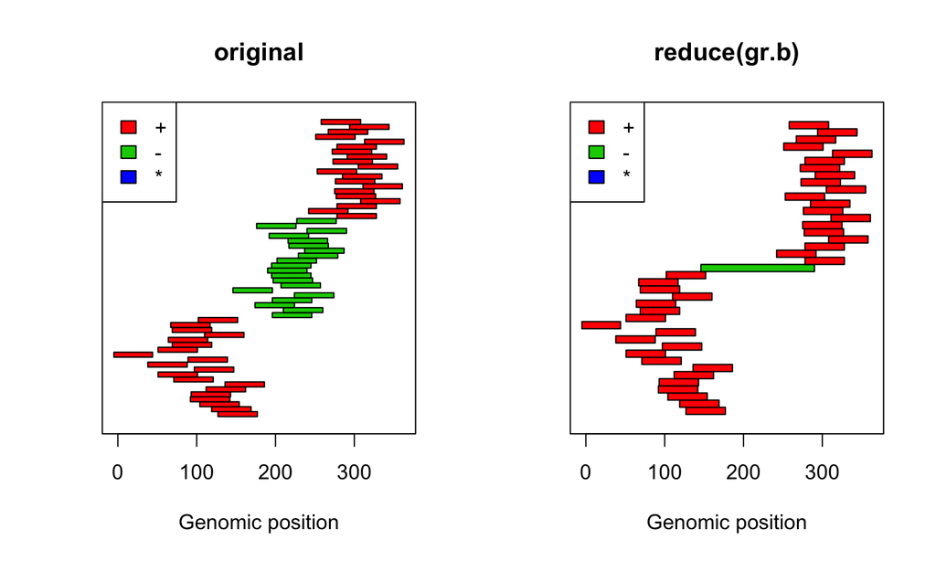

## GRanges reduce()

```r
gr.ab = reduce(c(gr.a,gr.b))
```

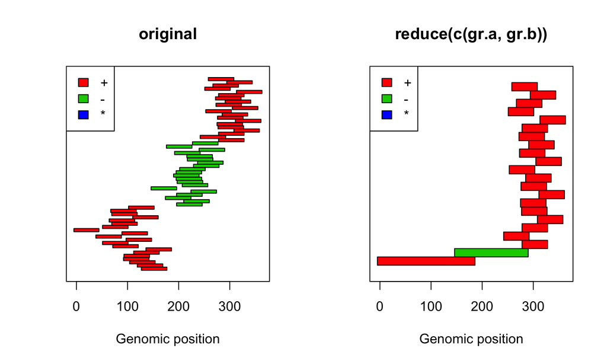

## GRanges reduce()

```r
gr.ab = reduce(c(gr.a,gr.b),ignore.strand=TRUE)
```

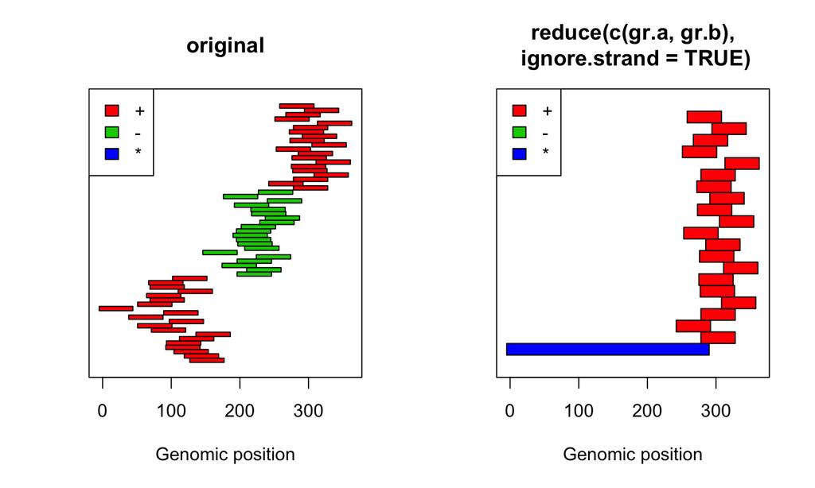

## Intersect of 2 GRanges

```r
gr.inter.ab = intersect(gr.a,gr.b)
```

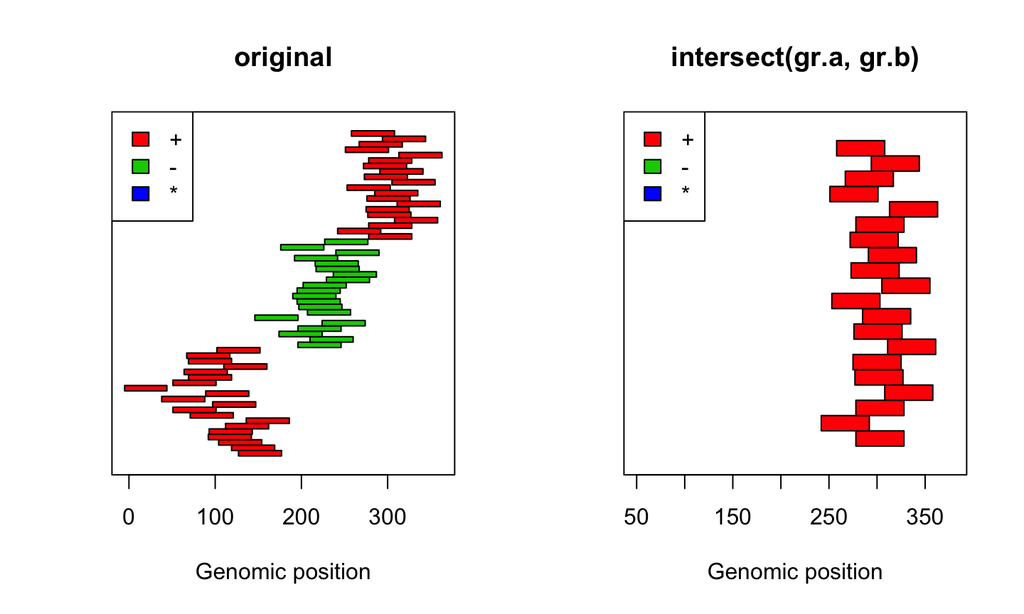

## Intersect of 2 GRanges

```r
gr.inter.ab = intersect(gr.a,gr.b,ignore.strand = TRUE)
```

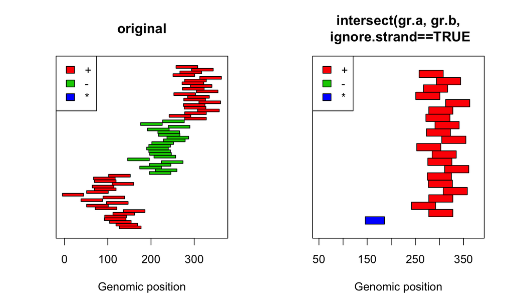

## Union of 2 GRanges

```r
gr.ab = union(gr.a,gr.b)
```

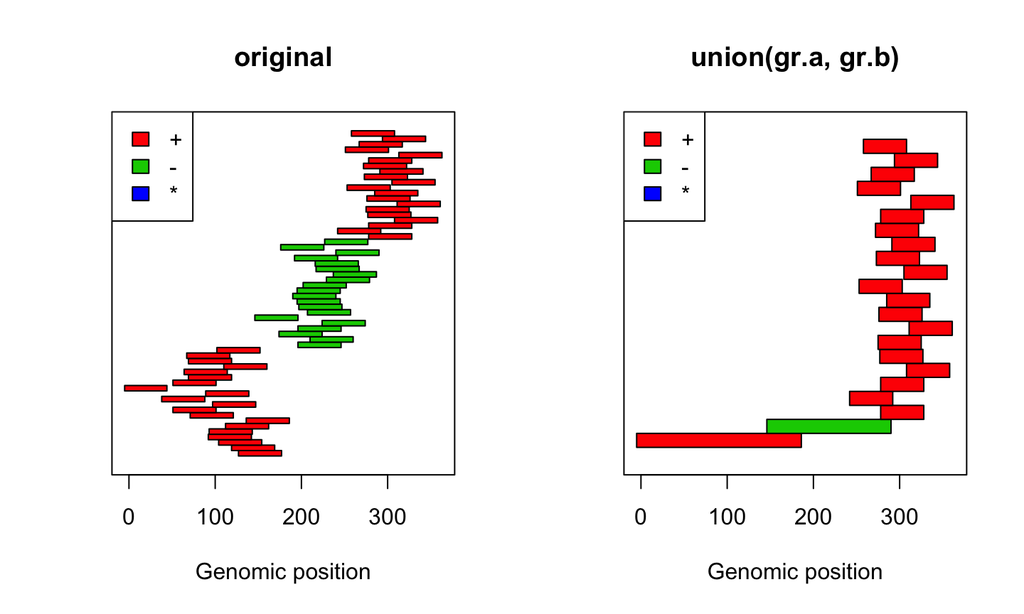

## Finding overlapping GRanges

```r
overlapsAny(gr.b, gr.c)
```

```
##  [1] FALSE FALSE FALSE FALSE FALSE FALSE FALSE FALSE FALSE FALSE FALSE
## [12] FALSE FALSE FALSE FALSE FALSE FALSE FALSE FALSE FALSE
```

```r
overlapsAny(gr.b, gr.c,ignore.strand=TRUE)
```

```
##  [1]  TRUE  TRUE FALSE  TRUE  TRUE FALSE  TRUE  TRUE  TRUE FALSE  TRUE
## [12]  TRUE  TRUE  TRUE  TRUE  TRUE  TRUE  TRUE FALSE  TRUE
```

## Finding overlapping GRanges

```r
gr.window = GRanges("seq1",IRanges(175,300),"*")
gr.overlapped = gr.abc[ overlapsAny(gr.abc, gr.window) ]
```

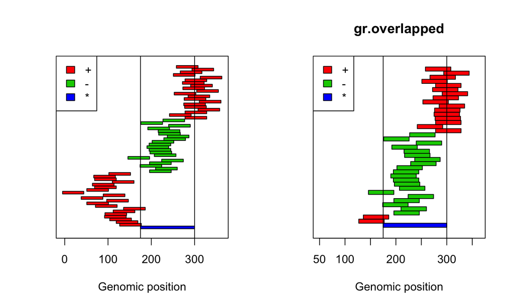

## coverage() function

```r
cov = coverage(gr.abc)
cov
```

```
## RleList of length 1
## $seq1
## integer-Rle of length 363 with 89 runs
##   Lengths: 37  7  6 13  3  2  2 21  1  4 ...  1  1  1  7  6  3 11  3  3  2
##   Values :  1  2  1  3  4  5  7  8  9 10 ... 12 11 10  7  6  5  4  3  2  1
```

## coverage() function

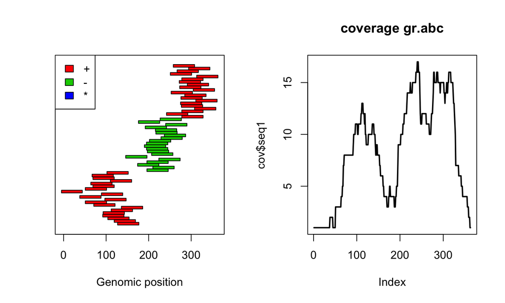

```r
plot(cov$seq1, type='l', lwd=2, main = "coverage gr.abc")
```

## A simple function to read GRanges from MACS output file

```r
load_peak_file = function(file,header=FALSE){
  peaks.df <-read.delim(file,header=header, comment.char="#",
                        stringsAsFactors = FALSE)
  if(sum(grepl(pattern = "chr",peaks.df[,1]))==0){
    peaks.df[,1]=paste("chr",peaks.df[,1],sep="")
  }
  peaks=GRanges(seqnames=peaks.df[,1],ranges=IRanges(peaks.df[,2], peaks.df[,3]))
  if (ncol(peaks.df) > 3) {
      mcols(peaks) <- peaks.df[, 4:ncol(peaks.df)]
  }
  peaks$filename = basename(file)
  peaks
}
```

## Loading some real data (H3K4me3 peaks from ENCODE)

```r
gr.H3K4me3 = load_peak_file("DATA/E116-H3K4me3.narrowPeak")
head(gr.H3K4me3, n=3)
```

```
## GRanges object with 3 ranges and 8 metadata columns:
##       seqnames                 ranges strand |          V4        V5
##          <Rle>              <IRanges>  <Rle> | <character> <integer>
##   [1]     chr9 [123553463, 123557122]      * |      Rank_1       623
##   [2]     chr3 [ 53196212,  53197995]      * |      Rank_2       622
##   [3]    chr18 [  9137533,   9142676]      * |      Rank_3       583
##                V6        V7        V8        V9       V10
##       <character> <numeric> <numeric> <numeric> <integer>
##   [1]           .  23.09216  62.34132  52.85911      1736
##   [2]           .  24.91976  62.22835  52.85911       439
##   [3]           .  22.48938  58.39180  50.67302       442
##                      filename
##                   <character>
##   [1] E116-H3K4me3.narrowPeak
##   [2] E116-H3K4me3.narrowPeak
##   [3] E116-H3K4me3.narrowPeak
##   -------
##   seqinfo: 23 sequences from an unspecified genome; no seqlengths
```

## GRangesList object

```r
grl = split(gr.H3K4me3, seqnames(gr.H3K4me3))
names(grl)
```

```
##  [1] "chr9"  "chr3"  "chr18" "chr11" "chr13" "chr1"  "chr10" "chr15"
##  [9] "chr5"  "chr2"  "chr22" "chr8"  "chr20" "chr17" "chr7"  "chr12"
## [17] "chr14" "chr6"  "chr19" "chr4"  "chr16" "chr21" "chrX"
```

```r
grl$chr1
```

```
## GRanges object with 7354 ranges and 8 metadata columns:
##          seqnames                 ranges strand   |          V4        V5
##             <Rle>              <IRanges>  <Rle>   | <character> <integer>
##      [1]     chr1 [160676101, 160681682]      *   |      Rank_6       541
##      [2]     chr1 [155242029, 155243137]      *   |     Rank_22       506
##      [3]     chr1 [ 33115473,  33116565]      *   |     Rank_26       499
##      [4]     chr1 [ 52868587,  52871706]      *   |     Rank_28       499
##      [5]     chr1 [173833356, 173837136]      *   |     Rank_31       496
##      ...      ...                    ...    ... ...         ...       ...
##   [7350]     chr1 [163293892, 163294130]      *   |  Rank_76102        20
##   [7351]     chr1 [ 42472348,  42472522]      *   |  Rank_76103        20
##   [7352]     chr1 [205712227, 205712599]      *   |  Rank_76119        20
##   [7353]     chr1 [169880087, 169880404]      *   |  Rank_76132        20
##   [7354]     chr1 [ 19807038,  19807241]      *   |  Rank_76150        20
##                   V6        V7        V8        V9       V10
```

[output cut: 27 more lines]

## Plotting peak distribution on chr1

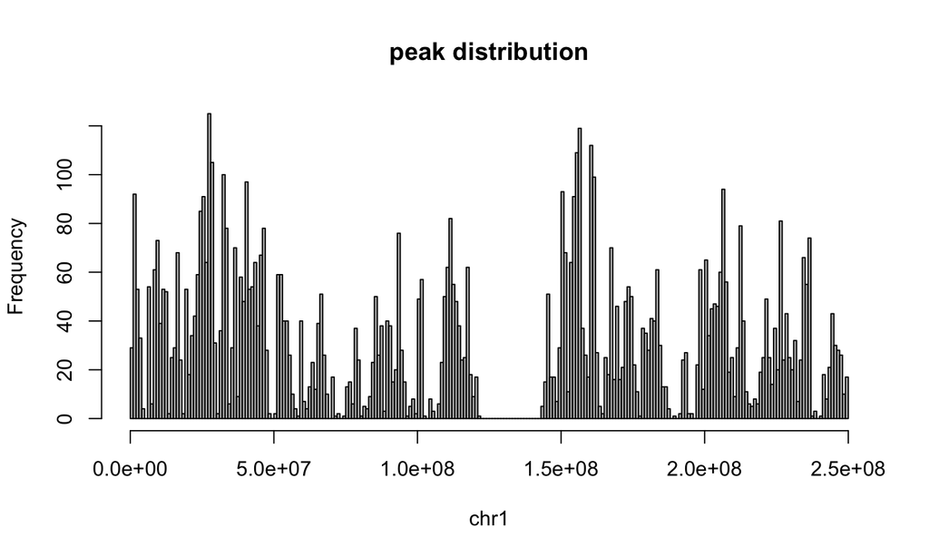

```r
hist(start(grl$chr1),breaks=200,col="grey",
     xlab="chr1",main="peak distribution")
```

## Example with RNAseq data

Adapted from "An Introduction to Genomic Ranges Classes" available at https://bioconductor.org/

- Read a bam file
- Load gene annotation
- Get the read counts by gene
- Plot read coverage for a specific gene
- Get the number of reads supporting splice junctions

## Load appropriate packages

```r
#Class for handling genomic alignments
library(GenomicAlignments)

#Gene annotations for Dmelanogaster
library(TxDb.Dmelanogaster.UCSC.dm3.ensGene)

#An RNAseq dataset
library(pasillaBamSubset)
```

## Loading a BAM file as a GAlignements object

```r
# Path to the example BAM
un1 <- untreated1_chr4()

gr.gal <- readGAlignments(un1) #Reading the BAM file

head(gr.gal,n=3) #Look at the first 3 alignments
```

```
## GAlignments object with 3 alignments and 0 metadata columns:
##       seqnames strand       cigar    qwidth     start       end     width
##          <Rle>  <Rle> <character> <integer> <integer> <integer> <integer>
##   [1]     chr4      -         75M        75       892       966        75
##   [2]     chr4      -         75M        75       919       993        75
##   [3]     chr4      +         75M        75       924       998        75
##           njunc
##       <integer>
##   [1]         0
##   [2]         0
##   [3]         0
##   -------
##   seqinfo: 8 sequences from an unspecified genome
```

## Extracting gene models

```r
#Get a GRangesList containig the exons for each gene
exbygene <- exonsBy(TxDb.Dmelanogaster.UCSC.dm3.ensGene, "gene")

exbygene
```

```
## GRangesList object of length 15682:
## $FBgn0000003
## GRanges object with 1 range and 2 metadata columns:
##       seqnames             ranges strand |   exon_id   exon_name
##          <Rle>          <IRanges>  <Rle> | <integer> <character>
##   [1]    chr3R [2648220, 2648518]      + |     45123        <NA>
##
## $FBgn0000008
## GRanges object with 13 ranges and 2 metadata columns:
##        seqnames               ranges strand   | exon_id exon_name
##    [1]    chr2R [18024494, 18024531]      +   |   20314      <NA>
##    [2]    chr2R [18024496, 18024713]      +   |   20315      <NA>
##    [3]    chr2R [18024938, 18025756]      +   |   20316      <NA>
##    [4]    chr2R [18025505, 18025756]      +   |   20317      <NA>
##    [5]    chr2R [18039159, 18039200]      +   |   20322      <NA>
##    ...      ...                  ...    ... ...     ...       ...
##    [9]    chr2R [18058283, 18059490]      +   |   20326      <NA>
##   [10]    chr2R [18059587, 18059757]      +   |   20327      <NA>
##   [11]    chr2R [18059821, 18059938]      +   |   20328      <NA>
##   [12]    chr2R [18060002, 18060339]      +   |   20329      <NA>
##   [13]    chr2R [18060002, 18060346]      +   |   20330      <NA>
##
## ...
## <15680 more elements>
## -------
## seqinfo: 15 sequences (1 circular) from dm3 genome
```

## Get the read counts by gene

```r
# This function performs similarly to HTSeq-count
se <- summarizeOverlaps(exbygene, un1, mode="IntersectionNotEmpty")

# Extract count matrix from se object
counts = assays(se)$counts

head(counts) #===> Ready for edgeR or DESeq analysis
```

```
##             untreated1_chr4.bam
## FBgn0000003                   0
## FBgn0000008                   0
## FBgn0000014                   0
## FBgn0000015                   0
## FBgn0000017                   0
## FBgn0000018                   0
```

## Get the gene model of a gene of interest

```r
# Lets take the one with the maximum number of counts
counts[which.max(counts[,1]),,drop=FALSE] # Well this is R...
```

```
##             untreated1_chr4.bam
## FBgn0017545               20390
```

```r
# Get its gene model (list of exons)
gr.exons = exbygene[["FBgn0017545"]]

gr.exons
```

```
## GRanges object with 7 ranges and 2 metadata columns:
##       seqnames         ranges strand |   exon_id   exon_name
##          <Rle>      <IRanges>  <Rle> | <integer> <character>
##   [1]     chr4 [85851, 86147]      - |     63180        <NA>
##   [2]     chr4 [86626, 86675]      - |     63182        <NA>
##   [3]     chr4 [86731, 87364]      - |     63183        <NA>
##   [4]     chr4 [86823, 87364]      - |     63184        <NA>
##   [5]     chr4 [87466, 87617]      - |     63185        <NA>
##   [6]     chr4 [87466, 87833]      - |     63186        <NA>
##   [7]     chr4 [87674, 87833]      - |     63187        <NA>
##   -------
##   seqinfo: 15 sequences (1 circular) from dm3 genome
```

## Define a gene region for plotting purpose

```r
#Define the gene region
gr.gene = range(gr.exons) # min & max coordinate as a GRanges

#Define the exonic region
gr.exonic = reduce(gr.exons) #All the positions covered by at lest one exon
```

## Get the coverage for that region

```r
gr.cov = as(coverage(gr.gal),"GRanges") #Coerce Rle to GRanges

gr.cov = gr.cov[overlapsAny(gr.cov, gr.gene)] #Keep gene region
```

## Plot coverage & exonic region

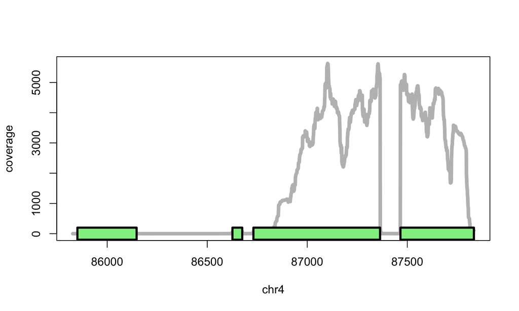

```r
plot(start(gr.cov),gr.cov$score,type='l',lwd=5,xlab="chr4",ylab="coverage",col="grey")
rect(start(gr.exonic),-200,end(gr.exonic),200,col="lightgreen",lwd=3)
```

## Get the number of reads supporting splice junctions

```r
gr.junc = summarizeJunctions(gr.gal)
gr.sel.junc = gr.junc[overlapsAny(gr.junc, gr.gene)]
gr.junc # A GRanges
```

```
## GRanges object with 910 ranges and 3 metadata columns:
##         seqnames             ranges strand   |     score plus_score
##            <Rle>          <IRanges>  <Rle>   | <integer>  <integer>
##     [1]     chr4     [ 5246, 11972]      *   |         3          1
##     [2]     chr4     [10346, 10637]      *   |         1          1
##     [3]     chr4     [27102, 27166]      *   |        13         11
##     [4]     chr4     [27102, 33948]      *   |        13         11
##     [5]     chr4     [27102, 48328]      *   |        13         11
##     ...      ...                ...    ... ...       ...        ...
##   [906]     chr4 [1320157, 1320219]      *   |         4          0
##   [907]     chr4 [1333112, 1346004]      *   |         1          0
##   [908]     chr4 [1333752, 1346734]      *   |         1          0
##   [909]     chr4 [1334150, 1347141]      *   |         1          1
##   [910]     chr4 [1334557, 1347539]      *   |         1          0
##         minus_score
##           <integer>
##     [1]           2
##     [2]           0
##     [3]           2
##     [4]           2
##     [5]           2
##     ...         ...
##   [906]           4
##   [907]           1
##   [908]           1
##   [909]           0
##   [910]           1
##   -------
##   seqinfo: 8 sequences from an unspecified genome
```

## Last plot

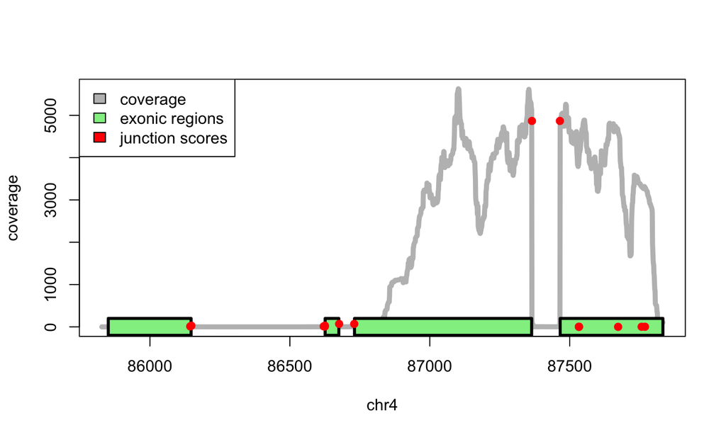

## Time for Knitr ?

*knitr in a knutshell*, a very nice tutorial by Karl Broman

http://kbroman.org/knitr_knutshell